## Project on Exploratory Data Analysis

# Company - Zomato

### Submitted by - Abhishek S Sharma

## Univiersity - IIT-Bombay

#### Roll no. - 205320002

[figure not shown]

```python
#importing libraries
import pandas as pd
import numpy as np
import matplotlib.pyplot as plt
import seaborn as sns

### so that u dont have warnings
from warnings import filterwarnings
filterwarnings('ignore')
```

```python
#reading dataset
df=pd.read_csv('zomato.csv')
df.head()
#information of each column is given on the top
```

|  | url | address | name | online_order | book_table | rate | votes | phone | location | rest_type | dish_liked | cuisines | approx_cost(for two people) | reviews_list | menu_item | listed_in(type) | listed_in(city) |
| --- | --- | --- | --- | --- | --- | --- | --- | --- | --- | --- | --- | --- | --- | --- | --- | --- | --- |
| 0 | https://www.zomato.com/bangalore/jalsa-banasha... | 942, 21st Main Road, 2nd Stage, Banashankari, ... | Jalsa | Yes | Yes | 4.1/5 | 775 | 080 42297555\r\n+91 9743772233 | Banashankari | Casual Dining | Pasta, Lunch Buffet, Masala Papad, Paneer Laja... | North Indian, Mughlai, Chinese | 800 | [('Rated 4.0', 'RATED\n A beautiful place to ... | [] | Buffet | Banashankari |
| 1 | https://www.zomato.com/bangalore/spice-elephan... | 2nd Floor, 80 Feet Road, Near Big Bazaar, 6th ... | Spice Elephant | Yes | No | 4.1/5 | 787 | 080 41714161 | Banashankari | Casual Dining | Momos, Lunch Buffet, Chocolate Nirvana, Thai G... | Chinese, North Indian, Thai | 800 | [('Rated 4.0', 'RATED\n Had been here for din... | [] | Buffet | Banashankari |
| 2 | https://www.zomato.com/SanchurroBangalore?cont... | 1112, Next to KIMS Medical College, 17th Cross... | San Churro Cafe | Yes | No | 3.8/5 | 918 | +91 9663487993 | Banashankari | Cafe, Casual Dining | Churros, Cannelloni, Minestrone Soup, Hot Choc... | Cafe, Mexican, Italian | 800 | [('Rated 3.0', "RATED\n Ambience is not that ... | [] | Buffet | Banashankari |
| 3 | https://www.zomato.com/bangalore/addhuri-udupi... | 1st Floor, Annakuteera, 3rd Stage, Banashankar... | Addhuri Udupi Bhojana | No | No | 3.7/5 | 88 | +91 9620009302 | Banashankari | Quick Bites | Masala Dosa | South Indian, North Indian | 300 | [('Rated 4.0', "RATED\n Great food and proper... | [] | Buffet | Banashankari |
| 4 | https://www.zomato.com/bangalore/grand-village... | 10, 3rd Floor, Lakshmi Associates, Gandhi Baza... | Grand Village | No | No | 3.8/5 | 166 | +91 8026612447\r\n+91 9901210005 | Basavanagudi | Casual Dining | Panipuri, Gol Gappe | North Indian, Rajasthani | 600 | [('Rated 4.0', 'RATED\n Very good restaurant ... | [] | Buffet | Banashankari |

```python
df.shape
```

```
(51717, 17)
```

```python
df.dtypes
```

```
url                            object
address                        object
name                           object
online_order                   object
book_table                     object
rate                           object
votes                           int64
phone                          object
location                       object
rest_type                      object
dish_liked                     object
cuisines                       object
approx_cost(for two people)    object
reviews_list                   object
menu_item                      object
listed_in(type)                object
listed_in(city)                object
dtype: object
```

```python
#number of unique resteraunt
len(df['name'].unique())
```

```
8792
```

```python
#empty values
df.isna().sum()
```

```
url                                0
address                            0
name                               0
online_order                       0
book_table                         0
rate                            7775
votes                              0
phone                           1208
location                          21
rest_type                        227
dish_liked                     28078
cuisines                          45
approx_cost(for two people)      346
reviews_list                       0
menu_item                          0
listed_in(type)                    0
listed_in(city)                    0
dtype: int64
```

```python
#getting the na values
```

```python
feature_na=[feature for feature in df.columns if df[feature].isnull().sum()>0]
feature_na
```

```
['rate',
 'phone',
 'location',
 'rest_type',
 'dish_liked',
 'cuisines',
 'approx_cost(for two people)']
```

```python
#% of missing values
for feature in feature_na:
    print('{} has {} % missing values'.format(feature,np.round(df[feature].isnull().sum()/len(df)*100,4)))
```

```
rate has 15.0337 % missing values
phone has 2.3358 % missing values
location has 0.0406 % missing values
rest_type has 0.4389 % missing values
dish_liked has 54.2916 % missing values
cuisines has 0.087 % missing values
approx_cost(for two people) has 0.669 % missing values
```

```python
df['rate'].unique()
```

```
array(['4.1/5', '3.8/5', '3.7/5', '3.6/5', '4.6/5', '4.0/5', '4.2/5',
       '3.9/5', '3.1/5', '3.0/5', '3.2/5', '3.3/5', '2.8/5', '4.4/5',
       '4.3/5', 'NEW', '2.9/5', '3.5/5', nan, '2.6/5', '3.8 /5', '3.4/5',
       '4.5/5', '2.5/5', '2.7/5', '4.7/5', '2.4/5', '2.2/5', '2.3/5',
       '3.4 /5', '-', '3.6 /5', '4.8/5', '3.9 /5', '4.2 /5', '4.0 /5',
       '4.1 /5', '3.7 /5', '3.1 /5', '2.9 /5', '3.3 /5', '2.8 /5',
       '3.5 /5', '2.7 /5', '2.5 /5', '3.2 /5', '2.6 /5', '4.5 /5',
       '4.3 /5', '4.4 /5', '4.9/5', '2.1/5', '2.0/5', '1.8/5', '4.6 /5',
       '4.9 /5', '3.0 /5', '4.8 /5', '2.3 /5', '4.7 /5', '2.4 /5',
       '2.1 /5', '2.2 /5', '2.0 /5', '1.8 /5'], dtype=object)
```

```python
df.dropna(axis='index',subset=['rate'],inplace=True)
```

```python
df.shape
```

```
(43942, 17)
```

```python
def split(x):
    return x.split('/')[0]
```

```python
df['rate']=df['rate'].apply(split)
```

```python
df.head()
```

|  | url | address | name | online_order | book_table | rate | votes | phone | location | rest_type | dish_liked | cuisines | approx_cost(for two people) | reviews_list | menu_item | listed_in(type) | listed_in(city) |
| --- | --- | --- | --- | --- | --- | --- | --- | --- | --- | --- | --- | --- | --- | --- | --- | --- | --- |
| 0 | https://www.zomato.com/bangalore/jalsa-banasha... | 942, 21st Main Road, 2nd Stage, Banashankari, ... | Jalsa | Yes | Yes | 4.1 | 775 | 080 42297555\r\n+91 9743772233 | Banashankari | Casual Dining | Pasta, Lunch Buffet, Masala Papad, Paneer Laja... | North Indian, Mughlai, Chinese | 800 | [('Rated 4.0', 'RATED\n A beautiful place to ... | [] | Buffet | Banashankari |
| 1 | https://www.zomato.com/bangalore/spice-elephan... | 2nd Floor, 80 Feet Road, Near Big Bazaar, 6th ... | Spice Elephant | Yes | No | 4.1 | 787 | 080 41714161 | Banashankari | Casual Dining | Momos, Lunch Buffet, Chocolate Nirvana, Thai G... | Chinese, North Indian, Thai | 800 | [('Rated 4.0', 'RATED\n Had been here for din... | [] | Buffet | Banashankari |
| 2 | https://www.zomato.com/SanchurroBangalore?cont... | 1112, Next to KIMS Medical College, 17th Cross... | San Churro Cafe | Yes | No | 3.8 | 918 | +91 9663487993 | Banashankari | Cafe, Casual Dining | Churros, Cannelloni, Minestrone Soup, Hot Choc... | Cafe, Mexican, Italian | 800 | [('Rated 3.0', "RATED\n Ambience is not that ... | [] | Buffet | Banashankari |
| 3 | https://www.zomato.com/bangalore/addhuri-udupi... | 1st Floor, Annakuteera, 3rd Stage, Banashankar... | Addhuri Udupi Bhojana | No | No | 3.7 | 88 | +91 9620009302 | Banashankari | Quick Bites | Masala Dosa | South Indian, North Indian | 300 | [('Rated 4.0', "RATED\n Great food and proper... | [] | Buffet | Banashankari |
| 4 | https://www.zomato.com/bangalore/grand-village... | 10, 3rd Floor, Lakshmi Associates, Gandhi Baza... | Grand Village | No | No | 3.8 | 166 | +91 8026612447\r\n+91 9901210005 | Basavanagudi | Casual Dining | Panipuri, Gol Gappe | North Indian, Rajasthani | 600 | [('Rated 4.0', 'RATED\n Very good restaurant ... | [] | Buffet | Banashankari |

```python
df.replace('NEW',0,inplace=True)
df.replace('-',0,inplace=True)
df['rate']=df['rate'].astype(float)
```

### Calculating average rating of each resturant

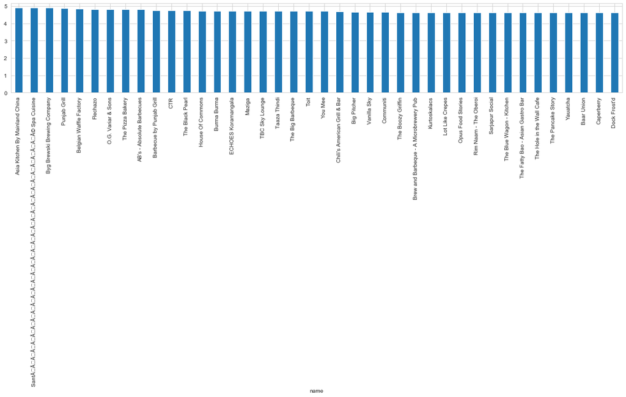

```python
plt.figure(figsize=(20,3))
df.groupby('name')['rate'].mean().nlargest(40).plot.bar()
plt.show()
```

```python
df_rate=df.groupby('name')['rate'].mean().to_frame()
df_rate=df_rate.reset_index()
df_rate.columns=['restaurant','rating']
df_rate.head(20)
```

|  | restaurant | rating |
| --- | --- | --- |
| 0 | #FeelTheROLL | 3.400000 |
| 1 | #L-81 Cafe | 3.900000 |
| 2 | #refuel | 3.700000 |
| 3 | 1000 B.C | 3.200000 |
| 4 | 100ÃÂÃÂÃÂÃÂ°C | 3.700000 |
| 5 | 11 to 11 Express Biriyanis | 3.500000 |
| 6 | 1131 Bar + Kitchen | 4.500000 |
| 7 | 12th Main - Grand Mercure | 4.100000 |
| 8 | 1441 Pizzeria | 4.100000 |
| 9 | 1522 - The Pub | 4.212000 |
| 10 | 154 Breakfast Club | 4.000000 |
| 11 | 1722 Urban Bistro | 4.100000 |
| 12 | 18+ Ice Cafe | 3.500000 |
| 13 | 1947 | 4.021429 |
| 14 | 1980s Games Cafe | 3.400000 |
| 15 | 1992 Chats - Space | 3.700000 |
| 16 | 1Q1 | 4.300000 |
| 17 | 1TO3 Kitchen | 3.100000 |
| 18 | 2 Statez | 3.700000 |
| 19 | 20 Char - Sterlings MAC Hotel | 4.000000 |

```python
df_rate.sort_values(by=['rating'],ascending=False)
df_new=df_rate[df_rate['rating']>4.5]
df_new.shape
df_new=df_new.sort_values(by=['rating'],ascending=False)
```

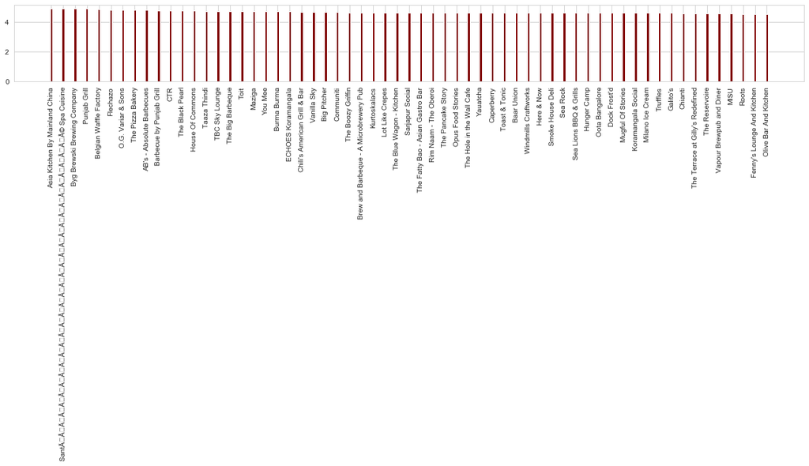

```python
#plotting the maximum values
plt.figure(figsize=(20,2))
plt.bar(df_new['restaurant'],df_new['rating'], color ='maroon',
        width =0.2)
plt.xticks(rotation=90)
plt.show()
```

### Rating distribution

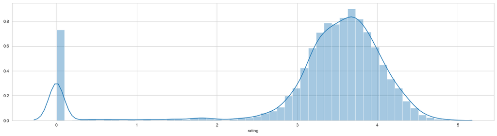

```python
plt.figure(figsize=(20,5))
sns.set_style(style='whitegrid')
sns.distplot(df_rate['rating'])
plt.show()
```

##### Almost more than 50 percent of restaurants has rating between 3 and 4. Restaurants having rating more than 4.5 are very rare.

```python
df_45=df_new[df_new['rating']>4.5]
df_45
```

|  | restaurant | rating |
| --- | --- | --- |
| 469 | Asia Kitchen By Mainland China | 4.900000 |
| 5345 | SantÃÂÃÂÃÂÃÂÃÂÃ... | 4.900000 |
| 1037 | Byg Brewski Brewing Company | 4.900000 |
| 4858 | Punjab Grill | 4.871429 |
| 690 | Belgian Waffle Factory | 4.844828 |
| ... | ... | ... |
| 6873 | Vapour Brewpub and Diner | 4.540000 |
| 3696 | MISU | 4.536842 |
| 5116 | Roots | 4.533333 |
| 2107 | Fenny's Lounge And Kitchen | 4.521429 |
| 4510 | Olive Bar And Kitchen | 4.520000 |

61 rows × 2 columns

### Which are the top restaurant franchise in Bangaluru?

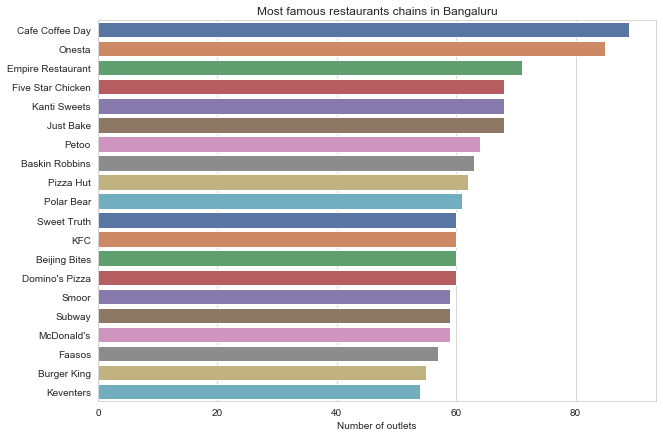

```python
plt.figure(figsize=(10,7))
rest=df['name'].value_counts()[0:20]
sns.barplot(x=rest,y=rest.index,palette='deep')
plt.title("Most famous restaurants chains in Bangaluru")
plt.xlabel("Number of outlets")
```

#### How many of the restuarants do not accept online orders?

```python
import plotly.express as px
x=df['online_order'].value_counts()
labels=['accepted','not accepted']
fig = px.pie(df, values=x, names=labels,title='Pie chart')
fig.show()
```

[interactive chart not shown]

#### How many types of restaurants we have?

```python
df['rest_type'].isna().sum()
```

```
151
```

```python
df['rest_type'].dropna(inplace=True)
```

```python
df['rest_type'].isna().sum()
```

```
0
```

```python
len(df['rest_type'].unique())
```

```
87
```

```python
trace1 = go.Bar(
        x = df['rest_type'].value_counts().nlargest(20).index,
        y = df['rest_type'].value_counts().nlargest(20),
        name= 'rest_type')
```

```python
from plotly.offline import iplot
iplot([trace1])
```

[interactive chart not shown]

##### At all, Banglore is known as the tech capital of India,people having busy and modern life will prefer Quick Bites.

##### We can observe tha Quick Bites type restaurants dominates.

#### Highest voted restaurant

```python
trace1 = go.Bar(
        x = df.groupby('name')['votes'].max().nlargest(10).index,
        y = df.groupby('name')['votes'].max().nlargest(10),
        name= 'name')
```

```python
iplot([trace1])
```

[interactive chart not shown]

### Total restaurants at different locations of Bengalore

```python
df.groupby('location')['name'].unique()
```

```
location
BTM                  [Sankranthi Veg Restaurant, Hearts Unlock Cafe...
Banashankari         [Jalsa, Spice Elephant, San Churro Cafe, Addhu...
Banaswadi            [Cafe Nibras, The Sanctuary, Crunch Pizzas, Pi...
Bannerghatta Road    [Deja Vu Resto Bar, Fattoush, Empire Restauran...
Basavanagudi         [Grand Village, Timepass Dinner, Srinathji's C...
                                           ...
West Bangalore       [FreshMenu, Fit Dish Fetish, Garden City Mobil...
Whitefield           [Imperio Cafe, Night Diaries, LocalHost, AB's ...
Wilson Garden        [Tree Top, Sahana's (Nati Style), Karavali Kol...
Yelahanka            [Prashanth Naati Corner, Cheta's Kitchen, Twis...
Yeshwantpur          [Chef's Bank, New Agarwal Bhavan, Fishing Boat...
Name: name, Length: 92, dtype: object
```

```python
restaurant=[]
location=[]
for key,location_df in df.groupby('location'):
    location.append(key)
    restaurant.append(len(location_df['name'].unique()))
```

```python
df_total=pd.DataFrame(zip(location,restaurant))
df_total.columns=['location','restaurant']
df_total.set_index('location',inplace=True)
df_total.sort_values(by='restaurant').tail(10)
```

| location | restaurant |
| --- | --- |
| Bellandur | 284 |
| Jayanagar | 311 |
| Bannerghatta Road | 362 |
| JP Nagar | 400 |
| Indiranagar | 467 |
| Electronic City | 518 |
| Marathahalli | 525 |
| HSR | 553 |
| BTM | 581 |
| Whitefield | 634 |

```python
df_total.sort_values(by='restaurant').tail(10).index
```

```
Index(['Bellandur', 'Jayanagar', 'Bannerghatta Road', 'JP Nagar',
       'Indiranagar', 'Electronic City', 'Marathahalli', 'HSR', 'BTM',
       'Whitefield'],
      dtype='object', name='location')
```

```python
trace1 = go.Bar(
        x = df_total['restaurant'].nlargest(10).index,
        y = df_total['restaurant'].nlargest(10),
        name= 'Priority')
```

```python
iplot([trace1])
```

[interactive chart not shown]

```python
df.isnull().sum()
```

```
url                                0
address                            0
name                               0
online_order                       0
book_table                         0
rate                               0
votes                              0
phone                            832
location                           0
rest_type                        151
dish_liked                     20333
cuisines                          11
approx_cost(for two people)      252
reviews_list                       0
menu_item                          0
listed_in(type)                    0
listed_in(city)                    0
dtype: int64
```

### Total number of variety of restaurants

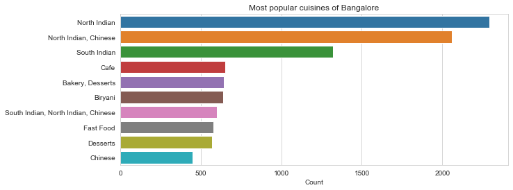

```python
plt.figure(figsize=(10,4))
cuisines=df['cuisines'].value_counts()[:10]
sns.barplot(cuisines,cuisines.index)
plt.xlabel('Count')
plt.title("Most popular cuisines of Bangalore")
```

```python
cuisines=df['cuisines'].value_counts()[:10]
trace1 = go.Bar(
        x = cuisines.index,
        y = cuisines,
        name= 'Cuisines')
```

```python
iplot([trace1])
```

[interactive chart not shown]

### We can clearly observe that North Indian,chinese,South Indian dominates the chart.

### It means Bengalore is more influenced by North Indian culture more than South!!

### Analyse Approx cost for 2 people

```python
len(df['approx_cost(for two people)'].value_counts())
df['approx_cost(for two people)'].isna().sum()
df.dropna(axis='index',subset=['approx_cost(for two people)'],inplace=True)
df['approx_cost(for two people)'].isna().sum()
df['approx_cost(for two people)'].unique()
```

```
array(['800', '300', '600', '700', '550', '500', '450', '650', '400',
       '900', '200', '750', '150', '850', '100', '1,200', '350', '250',
       '950', '1,000', '1,500', '1,300', '199', '80', '1,100', '160',
       '1,600', '230', '130', '1,700', '1,400', '1,350', '2,200', '2,000',
       '1,800', '1,900', '180', '330', '2,500', '2,100', '3,000', '2,800',
       '3,400', '50', '40', '1,250', '3,500', '4,000', '2,400', '2,600',
       '1,450', '70', '3,200', '560', '240', '360', '6,000', '1,050',
       '2,300', '4,100', '120', '5,000', '3,700', '1,650', '2,700',
       '4,500'], dtype=object)
```

```python
def is_float(x):
    try:
        float(x)
    except:
        return False
    return True
```

```python
df[~df['approx_cost(for two people)'].apply(is_float)]
```

|  | url | address | name | online_order | book_table | rate | votes | phone | location | rest_type | dish_liked | cuisines | approx_cost(for two people) | reviews_list | menu_item | listed_in(type) | listed_in(city) |
| --- | --- | --- | --- | --- | --- | --- | --- | --- | --- | --- | --- | --- | --- | --- | --- | --- | --- |
| 67 | https://www.zomato.com/gustoesbeerhouse?contex... | 10, 30th Main, Deve Gowda Petrol Bunk Road, 3r... | Gustoes Beer House | No | No | 4.1 | 868 | 080 49653521 | Banashankari | Pub | Beer, Wedges, Pizza, Nachos, Salads, Papaya Sa... | Continental, Italian, Mexican, North Indian, C... | 1,200 | [('Rated 5.0', 'RATED\n Has a really calm roo... | [] | Delivery | Banashankari |
| 119 | https://www.zomato.com/bangalore/k27-the-pub-b... | 27, 27th Cross, 2nd Stage, Banashankari, Banga... | K27 - The Pub | No | No | 3.1 | 30 | +91 9980097472 | Banashankari | Bar | NaN | Chinese, North Indian | 1,000 | [('Rated 4.0', "RATED\n Convenient and Averag... | [] | Delivery | Banashankari |
| 166 | https://www.zomato.com/bangalore/patio-805-jay... | 805, Ground Floor, 35C Cross, 9th Main, 4th Bl... | Patio 805 | Yes | Yes | 4.1 | 364 | +91 8884999805 | Jayanagar | Casual Dining | Noodles, Laksa Soup, Coffee, Veg Fritters, Veg... | Thai, Vietnamese, Asian, Chinese | 1,200 | [('Rated 4.0', "RATED\n The number of good re... | [] | Delivery | Banashankari |
| 207 | https://www.zomato.com/bangalore/chutney-chang... | Cosmopolitan Club, 22nd Cross, 3rd Block, Jaya... | Chutney Chang | Yes | Yes | 4.1 | 2339 | 080 22443007\r\n+91 9901967373 | Jayanagar | Casual Dining | Veg Momos, Brownie Chocolate, Palak Chaat, Mut... | North Indian, Chinese, BBQ | 1,500 | [('Rated 4.0', 'RATED\n Great place for team ... | [] | Delivery | Banashankari |
| 217 | https://www.zomato.com/bangalore/toscano-jayan... | 359/38,Next to Fabindia, 7th Cross, 1st Block,... | Toscano | Yes | Yes | 4.3 | 1129 | 080 41558423\r\n+91 7619320074 | Jayanagar | Casual Dining | Pizza, Pasta, Salads, Calamari, Ravioli, Pumpk... | Italian, Salad | 1,300 | [('Rated 4.0', 'RATED\n Saturday Night Dinner... | [] | Delivery | Banashankari |
| ... | ... | ... | ... | ... | ... | ... | ... | ... | ... | ... | ... | ... | ... | ... | ... | ... | ... |
| 51707 | https://www.zomato.com/bangalore/m-bar-bengalu... | Bengaluru Marriott Hotel, 75, 8th Road, EPIP A... | M Bar - Bengaluru Marriott Hotel Whitefield | No | No | 3.9 | 77 | 080 49435000 | Whitefield | Fine Dining, Bar | Rooftop Ambience | Finger Food | 2,000 | [('Rated 4.0', 'RATED\n Went there post dinne... | [] | Pubs and bars | Whitefield |
| 51708 | https://www.zomato.com/bangalore/keys-cafe-key... | Keys Hotel, 6, 1st Phase Industrial Area, Near... | Keys Cafe - Keys Hotel | No | No | 2.8 | 161 | 080 39451000\n+91 8884038484 | Whitefield | Casual Dining, Bar | Salads, Coffee, Breakfast Buffet, Halwa, Chick... | Chinese, Continental, North Indian | 1,200 | [('Rated 3.0', 'RATED\n Place is good not tha... | [] | Pubs and bars | Whitefield |
| 51712 | https://www.zomato.com/bangalore/best-brews-fo... | Four Points by Sheraton Bengaluru, 43/3, White... | Best Brews - Four Points by Sheraton Bengaluru... | No | No | 3.6 | 27 | 080 40301477 | Whitefield | Bar | NaN | Continental | 1,500 | [('Rated 5.0', "RATED\n Food and service are ... | [] | Pubs and bars | Whitefield |
| 51715 | https://www.zomato.com/bangalore/chime-sherato... | Sheraton Grand Bengaluru Whitefield Hotel & Co... | Chime - Sheraton Grand Bengaluru Whitefield Ho... | No | Yes | 4.3 | 236 | 080 49652769 | ITPL Main Road, Whitefield | Bar | Cocktails, Pizza, Buttermilk | Finger Food | 2,500 | [('Rated 4.0', 'RATED\n Nice and friendly pla... | [] | Pubs and bars | Whitefield |
| 51716 | https://www.zomato.com/bangalore/the-nest-the-... | ITPL Main Road, KIADB Export Promotion Industr... | The Nest - The Den Bengaluru | No | No | 3.4 | 13 | +91 8071117272 | ITPL Main Road, Whitefield | Bar, Casual Dining | NaN | Finger Food, North Indian, Continental | 1,500 | [('Rated 5.0', 'RATED\n Great ambience , look... | [] | Pubs and bars | Whitefield |

6798 rows × 17 columns

```python
df['approx_cost(for two people)'].dtype
df['approx_cost(for two people)']
df['approx_cost(for two people)'] = df['approx_cost(for two people)'].apply(lambda x: x.replace(',',''))
df['approx_cost(for two people)']=df['approx_cost(for two people)'].astype(int)
```

## Cost vs Rating

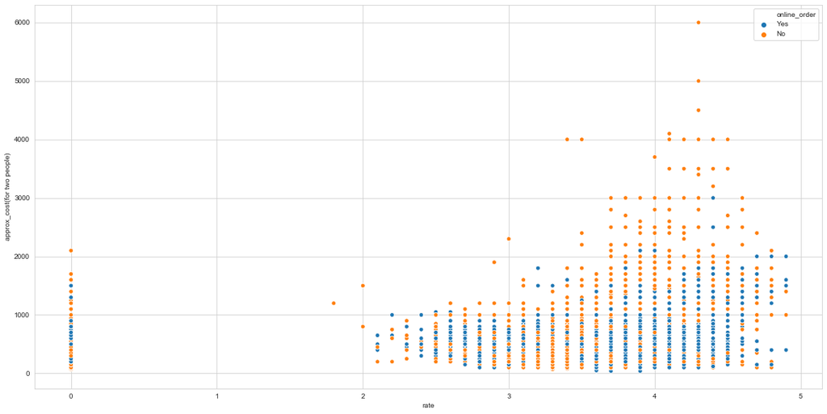

```python
plt.figure(figsize=(20,10))
sns.scatterplot(x="rate",y='approx_cost(for two people)',hue='online_order',data=df)
plt.show()
```

### From this scattterplot we can conclude that most of the highest rated restaurants accepts online order

#### Q- Is there any difference b/w price of restaurants accepting and not accepting online orders?

```python
fig = px.box(df,x='online_order',y='approx_cost(for two people)',notched=True)
fig.show()
```

[interactive chart not shown]

#### We can clearly see by the box plot that the restaurants accepting online orders are more affordable than restaurants who are accepting online orders

### Cheapest Rate for 2 people

```python
df['approx_cost(for two people)'].min()
```

```
40
```

##### Distribution of cost for 2 people

```python
plt.figure(figsize=(6,6))
px.histogram(df,x='approx_cost(for two people)')
```

[interactive chart not shown]

### Q- Most costly Rate for 2 people is served at which Restaurant what exactly is the dish involved in this and liked dish of that restaurant?

```python
df[df['approx_cost(for two people)']==6000].loc[:,('name','cuisines','dish_liked')]
```

|  | name | cuisines | dish_liked |
| --- | --- | --- | --- |
| 19139 | Le Cirque Signature - The Leela Palace | French, Italian | Wine, Asparagus Soup, Creme Brulee, Pasta, Rav... |
| 45618 | Le Cirque Signature - The Leela Palace | French, Italian | Wine, Asparagus Soup, Creme Brulee, Pasta, Rav... |

```python
my_data=df.copy()
```

```python
my_data.set_index('name',inplace=True)
```

```python
trace1 = go.Bar(
        x = my_data['approx_cost(for two people)'].nlargest(10).index,
        y = my_data['approx_cost(for two people)'].nlargest(10),
        name= 'Priority')
iplot([trace1])
```

[interactive chart not shown]

### These are the most expensive restaraunt

### Top 10 Cheapest restaurant with approx cost for 2 people

```python
trace1 = go.Bar(
        x = my_data['approx_cost(for two people)'].nsmallest(10).index,
        y = my_data['approx_cost(for two people)'].nsmallest(10),
        name= 'Priority')
iplot([trace1])
```

[interactive chart not shown]

#### We can see Srinidhi Sagar come amongst the cheapest restaraunts

### Restautants that are below than 500(budget hotel)

```python
my_data[my_data['approx_cost(for two people)']<=500]
```

| name | url | address | online_order | book_table | rate | votes | phone | location | rest_type | dish_liked | cuisines | approx_cost(for two people) | reviews_list | menu_item | listed_in(type) | listed_in(city) |
| --- | --- | --- | --- | --- | --- | --- | --- | --- | --- | --- | --- | --- | --- | --- | --- | --- |
| Addhuri Udupi Bhojana | https://www.zomato.com/bangalore/addhuri-udupi... | 1st Floor, Annakuteera, 3rd Stage, Banashankar... | No | No | 3.7 | 88 | +91 9620009302 | Banashankari | Quick Bites | Masala Dosa | South Indian, North Indian | 300 | [('Rated 4.0', "RATED\n Great food and proper... | [] | Buffet | Banashankari |
| CafÃÂÃÂÃÂÃÂ© Down The Alley | https://www.zomato.com/bangalore/caf%C3%A9-dow... | 12,29 Near PES University Back Gate, D'Souza N... | Yes | No | 4.1 | 402 | 080 26724489\r\n+91 7406048982 | Banashankari | Cafe | Waffles, Pasta, Crispy Chicken, Honey Chilli C... | Cafe | 500 | [('Rated 4.0', 'RATED\n We ended up here on a... | [] | Cafes | Banashankari |
| The Coffee Shack | https://www.zomato.com/bangalore/the-coffee-sh... | 6th Block, 3rd Stage, Banashankari, Bangalore | Yes | Yes | 4.2 | 164 | +91 9731644212 | Banashankari | Cafe | Coffee, Spaghetti, Pancakes, Nachos, Pasta, Sa... | Cafe, Chinese, Continental, Italian | 500 | [('Rated 4.0', "RATED\n Food - 4/5\nAmbience ... | [] | Cafes | Banashankari |
| Caf-Eleven | https://www.zomato.com/bangalore/caf-eleven-ba... | 111, Sapphire Toys Building, 100 Feet Ring Roa... | No | No | 4.0 | 424 | 080 49577715 | Banashankari | Cafe | Sandwich, Omelette, Ice Tea, Virgin Mojito, Ho... | Cafe, Continental | 450 | [('Rated 2.0', "RATED\n This is a hookah cafe... | [] | Cafes | Banashankari |
| T3H Cafe | https://www.zomato.com/bangalore/t3h-cafe-bana... | 504, CJ Venkata Das Road, Padmanabhangar, 2nd ... | No | No | 3.9 | 93 | +91 8884726600 | Banashankari | Cafe | Cheese Maggi, Peri Peri Fries, Pasta Arrabiata | Cafe, Italian, American | 300 | [('Rated 4.0', "RATED\n Happy to see such a c... | [] | Cafes | Banashankari |
| ... | ... | ... | ... | ... | ... | ... | ... | ... | ... | ... | ... | ... | ... | ... | ... | ... |
| Venice Kerala Restaurant | https://www.zomato.com/bangalore/venice-kerala... | Opposite Brookfield Mall, Shiva Temple Road, B... | No | No | 3.7 | 34 | +91 8880059495 | Brookefield | Quick Bites | NaN | Kerala | 200 | [('Rated 5.0', 'RATED\n Loved this restaurant... | [] | Dine-out | Whitefield |
| Thai & Chinese Fast Food | https://www.zomato.com/bangalore/thai-chinese-... | 7, Anurhh Arcade, Hoodi Road, Kodigehalli Road... | No | No | 3.4 | 7 | +91 9206260085\n+91 7619416923 | KR Puram | Quick Bites | NaN | Chinese, Thai | 400 | [('Rated 5.0', 'RATED\n Its Looking delicious... | [] | Dine-out | Whitefield |
| The Crunch | https://www.zomato.com/bangalore/the-crunch-br... | 33/1, Kundalahalli Road, Brookefield, Bangalore | No | No | 3.3 | 6 | +91 9016277963 | Brookefield | Beverage Shop | NaN | Beverages | 300 | [('Rated 3.0', 'RATED\n the sandwich was not ... | [] | Dine-out | Whitefield |
| Punjabi Charchay | https://www.zomato.com/bangalore/punjabi-charc... | 7, Anurhh Arcade, Hoodi Road, Kodigehalli Road... | No | No | 3.6 | 31 | +91 9341341916\n+91 7619416499 | KR Puram | Quick Bites | NaN | North Indian, Chinese | 400 | [('Rated 3.0', 'RATED\n A nice little place f... | [] | Dine-out | Whitefield |
| Raapchick | https://www.zomato.com/bangalore/raapchick-bro... | Opposite Brookefield Mall, Kundanhalli, Brooke... | Yes | No | 3.6 | 49 | 080 41717785\n+91 9571153004 | Brookefield | Quick Bites | Burgers | Fast Food, Burger | 300 | [('Rated 5.0', "RATED\n I was randomly lookin... | ['Chicken Wrap', 'Veg Crunch Burger', 'Spicy P... | Dine-out | Whitefield |

26330 rows × 16 columns

### Total no. of Restaurants that have better rating >4 and that are under budget too ie less than 500

```python
df_new=df[(df['rate']>=4) & (df['approx_cost(for two people)']<=500)]
len(df_new['name'].unique())
```

```
628
```

### Total such various affordable hotels at different location

```python
location=[]
total=[]
for loc,location_df in df_new.groupby('location'):
    location.append(loc)
    total.append(len(location_df['name'].unique()))
```

```python
len(location)
len(total)
```

```
68
```

```python
location_df=pd.DataFrame(zip(location,total))
location_df.columns=['location','restaurant']
location_df.set_index('location',inplace=True)
```

```python
location_df.head(20)
```

| location | restaurant |
| --- | --- |
| BTM | 54 |
| Banashankari | 25 |
| Banaswadi | 3 |
| Bannerghatta Road | 19 |
| Basavanagudi | 31 |
| Basaveshwara Nagar | 3 |
| Bellandur | 20 |
| Brigade Road | 11 |
| Brookefield | 16 |
| Church Street | 8 |
| City Market | 1 |
| Commercial Street | 4 |
| Cunningham Road | 4 |
| Domlur | 5 |
| Ejipura | 1 |
| Electronic City | 23 |
| Frazer Town | 15 |
| HBR Layout | 3 |
| HSR | 58 |
| Hebbal | 1 |

```python
trace1 = go.Bar(
        x = location_df['restaurant'].nlargest(10).index,
        y = location_df['restaurant'].nlargest(10),
        name= 'Priority')
iplot([trace1])
```

[interactive chart not shown]

## Geographical analysis

#### For fetching latitudes & longitudes for each restaraunts we can use Geopy

```python
locations=pd.DataFrame({"Name":df['location'].unique()})
```

```python
from geopy.geocoders import Nominatim
```

```python
lat_lon=[]
geolocator=Nominatim(user_agent="app")
for location in locations['Name']:
    location = geolocator.geocode(location)
    if location is None:
        lat_lon.append(np.nan)
    else:
        geo=(location.latitude,location.longitude)
        lat_lon.append(geo)
```

```python
locations['geo_loc']=lat_lon
```

```python
locations.head()
```

|  | Name | geo_loc |
| --- | --- | --- |
| 0 | Banashankari | (15.8876779, 75.7046777) |
| 1 | Basavanagudi | (12.9417261, 77.5755021) |
| 2 | Mysore Road | (12.3872141, 76.6669626) |
| 3 | Jayanagar | (27.64392675, 83.05280519687284) |
| 4 | Kumaraswamy Layout | (12.9081487, 77.5553179) |

```python
locations.to_csv('zomato_locations.csv',index=False)
```

##### We have found out latitude and longitude of each location listed in the dataset using geopy.

##### This is used to plot maps.

```python
Rest_locations=pd.DataFrame(df['location'].value_counts().reset_index())
```

```python
Rest_locations.columns=['Name','count']
Rest_locations.head()
```

|  | Name | count |
| --- | --- | --- |
| 0 | BTM | 4237 |
| 1 | Koramangala 5th Block | 2358 |
| 2 | HSR | 2113 |
| 3 | Indiranagar | 1892 |
| 4 | JP Nagar | 1849 |

```python
Rest_locations.shape
```

```
(92, 2)
```

```python
Restaurant_locations=Rest_locations.merge(locations,on='Name',how="left").dropna()
Restaurant_locations.head()
```

|  | Name | count | geo_loc |
| --- | --- | --- | --- |
| 0 | BTM | 4237 | (45.95485055, -112.49659530324134) |
| 1 | Koramangala 5th Block | 2358 | (12.9343774, 77.628415) |
| 2 | HSR | 2113 | (18.1475, 41.538889) |
| 3 | Indiranagar | 1892 | (12.9732913, 77.6404672) |
| 4 | JP Nagar | 1849 | (12.2655944, 76.6465404) |

```python
Restaurant_locations['count'].max()
```

```
4237
```

```python
def generateBaseMap(default_location=[12.97, 77.59], default_zoom_start=12):
    base_map = folium.Map(location=default_location, zoom_start=default_zoom_start)
    return base_map
```

```python
len(Restaurant_locations['geo_loc'])
```

```
91
```

```python
Restaurant_locations.isna().sum()
```

```
Name       0
count      0
geo_loc    0
dtype: int64
```

```python
np.array(Restaurant_locations['geo_loc'])
```

```
array([(45.95485055, -112.49659530324134), (12.9343774, 77.628415),
       (18.1475, 41.538889), (12.9732913, 77.6404672),
       (12.2655944, 76.6465404), (27.64392675, 83.05280519687284),
       (44.3730577, -71.6118577), (12.9552572, 77.6984163),
       (12.887979, 77.5970812), (12.9400321, 77.6203272),
       (40.28745, -76.964526), (12.9302645, 77.6332585),
       (12.93577245, 77.66676103753434), (14.5395813, 121.070371),
       (-6.2659285, 106.7842561), (12.9242381, 77.6289059),
       (12.9778793, 77.6246697), (12.93433385, 77.63040639553275),
       (29.4534927, -98.6440138), (15.8876779, 75.7046777),
       (13.0221416, 77.6403368), (13.0027353, 77.5703253),
       (12.9417261, 77.5755021), (50.7721586, 0.09772783661369303),
       (38.7385916, -77.5275749), (33.5935063, -79.0345627),
       (12.996845, 77.6130165), (40.717732, -74.0057549),
       (13.0093455, 77.6377094), (13.0346384, 77.5681733),
       (40.7652844, -76.373824), (13.0141618, 77.6518539),
       (12.9882338, 77.554883), (31.89376, -88.066644),
       (12.9624669, 77.6381958), (12.9575547, 77.5979099),
       (62.442403, -114.3987951), (51.5230784, -0.7374421),
       (51.5154481, -0.0720271), (12.945245, 77.6269144),
       (18.5322493, 73.8499601124847), (12.9678074, 77.6568367),
       (12.988721250000001, 77.58516877601824), (12.9417812, 77.6160146),
       (12.9489339, 77.5968273), (12.9271867, 77.6266252),
       (12.9081487, 77.5553179), (13.2227, 78.5541977),
       (12.9089453, 77.6239038), (12.973936, 77.6509982),
       (12.9931876, 77.5753419), (12.9932739, 77.5388099),
       (34.977289, -78.974578), (1.306731, 103.8497839),
       (13.0258087, 77.6305067), (1.2847055, 103.84320655721689),
       (13.02383, 77.5529215), (13.0358698, 77.6323597),
       (12.9243509, 77.6255562), (12.9846713, 77.6790908),
       (13.0646907, 77.49626895712257), (12.9414662, 77.7470942),
       (12.967576, 77.7150877), (39.76880625, -86.15345077251979),
       (12.773175, 77.7831871), (6.9233338, 93.9046149),
       (17.2510682, 80.1651978), (13.0227204, 77.595715),
       (15.8782951, 74.5084834), (23.1485712, 81.6048241),
       (13.0621474, 77.58006135480495), (13.2923988, 77.7519261),
       (13.0215466, 77.7640586), (12.957998, 77.6037312),
       (38.7801076, -121.5056438), (12.945048, 77.263004),
       (11.9917786, 76.5066292), (12.9970537, 77.669804),
       (12.5607431, 77.4258375), (12.3872141, 76.6669626),
       (13.0217151, 77.7660547), (13.007516, 77.695935),
       (13.0382184, 77.5919), (12.9176571, 77.4837568),
       (12.9055682, 77.5455438), (13.0101286, 77.5548006),
       (13.0011289, 77.6325617), (13.1006982, 77.5963454),
       (12.9274413, 77.5155224), (12.9546741, 77.5121724),
       (13.0329419, 77.5273253)], dtype=object)
```

```python
#### unzip it
lat,lon=zip(*np.array(Restaurant_locations['geo_loc']))
```

```python
import folium
from folium.plugins import HeatMap
basemap=generateBaseMap()
```

```python
basemap
```

Make this Notebook Trusted to load map: File -> Trust Notebook

[interactive chart not shown]

```python
#Restaurant_locations[['lat','lon','count']].values.tolist()
Restaurant_locations['lat']=np.zeros([len(Restaurant_locations['geo_loc']),1]);
Restaurant_locations['lon']=np.zeros([len(Restaurant_locations['geo_loc']),1]);
for i in np.arange(0,73):
    Restaurant_locations['lat'][i]=Restaurant_locations['geo_loc'][i][0]
    Restaurant_locations['lon'][i]=Restaurant_locations['geo_loc'][i][1]
for i in np.arange(74,len(Restaurant_locations['geo_loc'])+1):
    Restaurant_locations['lat'][i]=Restaurant_locations['geo_loc'][i][0]
    Restaurant_locations['lon'][i]=Restaurant_locations['geo_loc'][i][1]
```

```python
Restaurant_locations['lat'][1]=Restaurant_locations['geo_loc'][1][0]
Restaurant_locations[:]
```

|  | Name | count | geo_loc | lat | lon |
| --- | --- | --- | --- | --- | --- |
| 0 | BTM | 4237 | (45.95485055, -112.49659530324134) | 45.954851 | -112.496595 |
| 1 | Koramangala 5th Block | 2358 | (12.9343774, 77.628415) | 12.934377 | 77.628415 |
| 2 | HSR | 2113 | (18.1475, 41.538889) | 18.147500 | 41.538889 |
| 3 | Indiranagar | 1892 | (12.9732913, 77.6404672) | 12.973291 | 77.640467 |
| 4 | JP Nagar | 1849 | (12.2655944, 76.6465404) | 12.265594 | 76.646540 |
| ... | ... | ... | ... | ... | ... |
| 87 | West Bangalore | 5 | (13.0011289, 77.6325617) | 13.001129 | 77.632562 |
| 88 | Yelahanka | 4 | (13.1006982, 77.5963454) | 13.100698 | 77.596345 |
| 89 | Rajarajeshwari Nagar | 2 | (12.9274413, 77.5155224) | 12.927441 | 77.515522 |
| 90 | Nagarbhavi | 1 | (12.9546741, 77.5121724) | 12.954674 | 77.512172 |
| 91 | Peenya | 1 | (13.0329419, 77.5273253) | 13.032942 | 77.527325 |

91 rows × 5 columns

```python
HeatMap(Restaurant_locations[['lat','lon','count']].values.tolist(),zoom=20,radius=15).add_to(basemap)
```

```
<folium.plugins.heat_map.HeatMap at 0x7ff4105c7a90>
```

```python
basemap
```

Make this Notebook Trusted to load map: File -> Trust Notebook

[interactive chart not shown]

##### It is clear that restaurants tend to concentrate in central bangalore area.

##### So,potential restaurant entrepreneurs can refer this and find out good locations for their venture.

### Heatmap of North Indian restaurants

```python
df.head()
```

|  | url | address | name | online_order | book_table | rate | votes | phone | location | rest_type | dish_liked | cuisines | approx_cost(for two people) | reviews_list | menu_item | listed_in(type) | listed_in(city) |
| --- | --- | --- | --- | --- | --- | --- | --- | --- | --- | --- | --- | --- | --- | --- | --- | --- | --- |
| 0 | https://www.zomato.com/bangalore/jalsa-banasha... | 942, 21st Main Road, 2nd Stage, Banashankari, ... | Jalsa | Yes | Yes | 4.1 | 775 | 080 42297555\r\n+91 9743772233 | Banashankari | Casual Dining | Pasta, Lunch Buffet, Masala Papad, Paneer Laja... | North Indian, Mughlai, Chinese | 800 | [('Rated 4.0', 'RATED\n A beautiful place to ... | [] | Buffet | Banashankari |
| 1 | https://www.zomato.com/bangalore/spice-elephan... | 2nd Floor, 80 Feet Road, Near Big Bazaar, 6th ... | Spice Elephant | Yes | No | 4.1 | 787 | 080 41714161 | Banashankari | Casual Dining | Momos, Lunch Buffet, Chocolate Nirvana, Thai G... | Chinese, North Indian, Thai | 800 | [('Rated 4.0', 'RATED\n Had been here for din... | [] | Buffet | Banashankari |
| 2 | https://www.zomato.com/SanchurroBangalore?cont... | 1112, Next to KIMS Medical College, 17th Cross... | San Churro Cafe | Yes | No | 3.8 | 918 | +91 9663487993 | Banashankari | Cafe, Casual Dining | Churros, Cannelloni, Minestrone Soup, Hot Choc... | Cafe, Mexican, Italian | 800 | [('Rated 3.0', "RATED\n Ambience is not that ... | [] | Buffet | Banashankari |
| 3 | https://www.zomato.com/bangalore/addhuri-udupi... | 1st Floor, Annakuteera, 3rd Stage, Banashankar... | Addhuri Udupi Bhojana | No | No | 3.7 | 88 | +91 9620009302 | Banashankari | Quick Bites | Masala Dosa | South Indian, North Indian | 300 | [('Rated 4.0', "RATED\n Great food and proper... | [] | Buffet | Banashankari |
| 4 | https://www.zomato.com/bangalore/grand-village... | 10, 3rd Floor, Lakshmi Associates, Gandhi Baza... | Grand Village | No | No | 3.8 | 166 | +91 8026612447\r\n+91 9901210005 | Basavanagudi | Casual Dining | Panipuri, Gol Gappe | North Indian, Rajasthani | 600 | [('Rated 4.0', 'RATED\n Very good restaurant ... | [] | Buffet | Banashankari |

```python
df2= df[df['cuisines']=='North Indian']
df2.head()
```

|  | url | address | name | online_order | book_table | rate | votes | phone | location | rest_type | dish_liked | cuisines | approx_cost(for two people) | reviews_list | menu_item | listed_in(type) | listed_in(city) |
| --- | --- | --- | --- | --- | --- | --- | --- | --- | --- | --- | --- | --- | --- | --- | --- | --- | --- |
| 5 | https://www.zomato.com/bangalore/timepass-dinn... | 37, 5-1, 4th Floor, Bosco Court, Gandhi Bazaar... | Timepass Dinner | Yes | No | 3.8 | 286 | +91 9980040002\r\n+91 9980063005 | Basavanagudi | Casual Dining | Onion Rings, Pasta, Kadhai Paneer, Salads, Sal... | North Indian | 600 | [('Rated 3.0', 'RATED\n Food 3/5\nAmbience 3/... | [] | Buffet | Banashankari |
| 50 | https://www.zomato.com/bangalore/petoo-banasha... | 276, Ground Floor, 100 Feet Outer Ring Road, B... | Petoo | No | No | 3.7 | 21 | +91 8026893211 | Banashankari | Quick Bites | NaN | North Indian | 450 | [('Rated 2.0', 'RATED\n This is a neatly made... | [] | Delivery | Banashankari |
| 72 | https://www.zomato.com/bangalore/spicy-tandoor... | Opposite ICICi Bank, Hanuman Nagar, Banashanka... | Spicy Tandoor | No | No | 0.0 | 0 | +91 8050884222 | Banashankari | Quick Bites | NaN | North Indian | 150 | [('Rated 4.0', 'RATED\n cost for chicken roll... | [] | Delivery | Banashankari |
| 87 | https://www.zomato.com/bangalore/krishna-sagar... | 38, 22nd Main, 22nd Cross, Opposite BDA, 2nd S... | Krishna Sagar | No | No | 3.5 | 31 | +91 8892752997\r\n+91 7204780429 | Banashankari | Quick Bites | NaN | North Indian | 200 | [('Rated 1.0', 'RATED\n Worst experience with... | [] | Delivery | Banashankari |
| 94 | https://www.zomato.com/bangalore/nandhini-delu... | 304, Opposite Apollo Public School, 100 Feet R... | Nandhini Deluxe | No | No | 2.6 | 283 | 080 26890011\r\n080 26890033 | Banashankari | Casual Dining | Biryani, Chicken Guntur, Thali, Buttermilk, Ma... | North Indian | 600 | [('Rated 3.0', 'RATED\n Ididnt like much.\n\n... | [] | Delivery | Banashankari |

```python
north_india=df2.groupby(['location'],as_index=False)['url'].agg('count')
north_india.columns=['Name','count']
north_india.head()
```

|  | Name | count |
| --- | --- | --- |
| 0 | BTM | 262 |
| 1 | Banashankari | 35 |
| 2 | Banaswadi | 9 |
| 3 | Bannerghatta Road | 60 |
| 4 | Basavanagudi | 17 |

```python
north_india=north_india.merge(locations,on="Name",how='left').dropna()
```

```python
north_india.head()
```

|  | Name | count | geo_loc |
| --- | --- | --- | --- |
| 0 | BTM | 262 | (45.95485055, -112.49659530324134) |
| 1 | Banashankari | 35 | (15.8876779, 75.7046777) |
| 2 | Banaswadi | 9 | (13.0141618, 77.6518539) |
| 3 | Bannerghatta Road | 60 | (12.887979, 77.5970812) |
| 4 | Basavanagudi | 17 | (12.9417261, 77.5755021) |

```python
north_india['lan'],north_india['lon']=zip(*north_india['geo_loc'].values)
```

```python
north_india.drop(['geo_loc'],axis=1)
```

|  | Name | count | lan | lon |
| --- | --- | --- | --- | --- |
| 0 | BTM | 262 | 45.954851 | -112.496595 |
| 1 | Banashankari | 35 | 15.887678 | 75.704678 |
| 2 | Banaswadi | 9 | 13.014162 | 77.651854 |
| 3 | Bannerghatta Road | 60 | 12.887979 | 77.597081 |
| 4 | Basavanagudi | 17 | 12.941726 | 77.575502 |
| ... | ... | ... | ... | ... |
| 58 | Varthur Main Road, Whitefield | 3 | 12.941466 | 77.747094 |
| 59 | Vasanth Nagar | 12 | 12.988721 | 77.585169 |
| 60 | Whitefield | 146 | 44.373058 | -71.611858 |
| 61 | Wilson Garden | 37 | 12.948934 | 77.596827 |
| 62 | Yeshwantpur | 3 | 13.023830 | 77.552921 |

63 rows × 4 columns

```python
basemap=generateBaseMap()
HeatMap(north_india[['lan','lon','count']].values.tolist(),zoom=20,radius=15).add_to(basemap)
basemap
```

Make this Notebook Trusted to load map: File -> Trust Notebook

[interactive chart not shown]

#### Wordcloud of dishes liked by cuisines.

```python
from wordcloud import WordCloud
```

```python
df.head()
```

|  | url | address | name | online_order | book_table | rate | votes | phone | location | rest_type | dish_liked | cuisines | approx_cost(for two people) | reviews_list | menu_item | listed_in(type) | listed_in(city) |
| --- | --- | --- | --- | --- | --- | --- | --- | --- | --- | --- | --- | --- | --- | --- | --- | --- | --- |
| 0 | https://www.zomato.com/bangalore/jalsa-banasha... | 942, 21st Main Road, 2nd Stage, Banashankari, ... | Jalsa | Yes | Yes | 4.1 | 775 | 080 42297555\r\n+91 9743772233 | Banashankari | Casual Dining | Pasta, Lunch Buffet, Masala Papad, Paneer Laja... | North Indian, Mughlai, Chinese | 800 | [('Rated 4.0', 'RATED\n A beautiful place to ... | [] | Buffet | Banashankari |
| 1 | https://www.zomato.com/bangalore/spice-elephan... | 2nd Floor, 80 Feet Road, Near Big Bazaar, 6th ... | Spice Elephant | Yes | No | 4.1 | 787 | 080 41714161 | Banashankari | Casual Dining | Momos, Lunch Buffet, Chocolate Nirvana, Thai G... | Chinese, North Indian, Thai | 800 | [('Rated 4.0', 'RATED\n Had been here for din... | [] | Buffet | Banashankari |
| 2 | https://www.zomato.com/SanchurroBangalore?cont... | 1112, Next to KIMS Medical College, 17th Cross... | San Churro Cafe | Yes | No | 3.8 | 918 | +91 9663487993 | Banashankari | Cafe, Casual Dining | Churros, Cannelloni, Minestrone Soup, Hot Choc... | Cafe, Mexican, Italian | 800 | [('Rated 3.0', "RATED\n Ambience is not that ... | [] | Buffet | Banashankari |
| 3 | https://www.zomato.com/bangalore/addhuri-udupi... | 1st Floor, Annakuteera, 3rd Stage, Banashankar... | Addhuri Udupi Bhojana | No | No | 3.7 | 88 | +91 9620009302 | Banashankari | Quick Bites | Masala Dosa | South Indian, North Indian | 300 | [('Rated 4.0', "RATED\n Great food and proper... | [] | Buffet | Banashankari |
| 4 | https://www.zomato.com/bangalore/grand-village... | 10, 3rd Floor, Lakshmi Associates, Gandhi Baza... | Grand Village | No | No | 3.8 | 166 | +91 8026612447\r\n+91 9901210005 | Basavanagudi | Casual Dining | Panipuri, Gol Gappe | North Indian, Rajasthani | 600 | [('Rated 4.0', 'RATED\n Very good restaurant ... | [] | Buffet | Banashankari |

```python
df['update_dish_liked']=df['dish_liked'].apply(lambda x : x.split(',') if type(x)==str else [''])
```

```python
df.head()
```

|  | url | address | name | online_order | book_table | rate | votes | phone | location | rest_type | dish_liked | cuisines | approx_cost(for two people) | reviews_list | menu_item | listed_in(type) | listed_in(city) | update_dish_liked |
| --- | --- | --- | --- | --- | --- | --- | --- | --- | --- | --- | --- | --- | --- | --- | --- | --- | --- | --- |
| 0 | https://www.zomato.com/bangalore/jalsa-banasha... | 942, 21st Main Road, 2nd Stage, Banashankari, ... | Jalsa | Yes | Yes | 4.1 | 775 | 080 42297555\r\n+91 9743772233 | Banashankari | Casual Dining | Pasta, Lunch Buffet, Masala Papad, Paneer Laja... | North Indian, Mughlai, Chinese | 800 | [('Rated 4.0', 'RATED\n A beautiful place to ... | [] | Buffet | Banashankari | [Pasta, Lunch Buffet, Masala Papad, Paneer ... |
| 1 | https://www.zomato.com/bangalore/spice-elephan... | 2nd Floor, 80 Feet Road, Near Big Bazaar, 6th ... | Spice Elephant | Yes | No | 4.1 | 787 | 080 41714161 | Banashankari | Casual Dining | Momos, Lunch Buffet, Chocolate Nirvana, Thai G... | Chinese, North Indian, Thai | 800 | [('Rated 4.0', 'RATED\n Had been here for din... | [] | Buffet | Banashankari | [Momos, Lunch Buffet, Chocolate Nirvana, Th... |
| 2 | https://www.zomato.com/SanchurroBangalore?cont... | 1112, Next to KIMS Medical College, 17th Cross... | San Churro Cafe | Yes | No | 3.8 | 918 | +91 9663487993 | Banashankari | Cafe, Casual Dining | Churros, Cannelloni, Minestrone Soup, Hot Choc... | Cafe, Mexican, Italian | 800 | [('Rated 3.0', "RATED\n Ambience is not that ... | [] | Buffet | Banashankari | [Churros, Cannelloni, Minestrone Soup, Hot ... |
| 3 | https://www.zomato.com/bangalore/addhuri-udupi... | 1st Floor, Annakuteera, 3rd Stage, Banashankar... | Addhuri Udupi Bhojana | No | No | 3.7 | 88 | +91 9620009302 | Banashankari | Quick Bites | Masala Dosa | South Indian, North Indian | 300 | [('Rated 4.0', "RATED\n Great food and proper... | [] | Buffet | Banashankari | [Masala Dosa] |
| 4 | https://www.zomato.com/bangalore/grand-village... | 10, 3rd Floor, Lakshmi Associates, Gandhi Baza... | Grand Village | No | No | 3.8 | 166 | +91 8026612447\r\n+91 9901210005 | Basavanagudi | Casual Dining | Panipuri, Gol Gappe | North Indian, Rajasthani | 600 | [('Rated 4.0', 'RATED\n Very good restaurant ... | [] | Buffet | Banashankari | [Panipuri, Gol Gappe] |

```python
df['rest_type'].value_counts()[:9].index
```

```
Index(['Quick Bites', 'Casual Dining', 'Cafe', 'Dessert Parlor', 'Delivery',
       'Takeaway, Delivery', 'Casual Dining, Bar', 'Bakery', 'Beverage Shop'],
      dtype='object')
```

```python
rest=df['rest_type'].value_counts()[:9].index
```

```python
from wordcloud import WordCloud, STOPWORDS
```

```python
df.isna().sum()
```

```
url                                0
address                            0
name                               0
online_order                       0
book_table                         0
rate                               0
votes                              0
phone                            591
location                           0
rest_type                        149
dish_liked                     20216
cuisines                           8
approx_cost(for two people)        0
reviews_list                       0
menu_item                          0
listed_in(type)                    0
listed_in(city)                    0
update_dish_liked                  0
dtype: int64
```

```python
df.dropna(axis='index',subset=['rest_type'],inplace=True)
```

```python
df.dropna(axis='index',subset=['dish_liked'],inplace=True)
```

```python
df.isna().sum()
```

```
url                              0
address                          0
name                             0
online_order                     0
book_table                       0
rate                             0
votes                            0
phone                          213
location                         0
rest_type                        0
dish_liked                       0
cuisines                         0
approx_cost(for two people)      0
reviews_list                     0
menu_item                        0
listed_in(type)                  0
listed_in(city)                  0
update_dish_liked                0
dtype: int64
```

##### wordcloud for 1 restaurant

```python
data=df[df['rest_type']=='Quick Bites']
```

```python
data['dish_liked']
```

```
3                                              Masala Dosa
31       Burgers, Lassi, Chicken Grill, Naan, Momos, Ch...
34       Rolls, Veggie Wrap, Chocolate Fantasy, Rice Bo...
40       Dabeli, Faluda, Masala Poori, Sandwiches, Tokr...
42                           Burgers, Fries, Hot Chocolate
                               ...
51598                          Potato Fries, Chicken Curry
51601    Rolls, Chicken Tikka Roll, Chicken Bhuna Roll,...
51617                               Coffee, Vada, Mla Dosa
51629                             Fish, Veg Thali, Biryani
51645                                              Burgers
Name: dish_liked, Length: 5269, dtype: object
```

```python
stopwords=set(STOPWORDS)
```

```
(-0.5, 1499.5, 1499.5, -0.5)
```

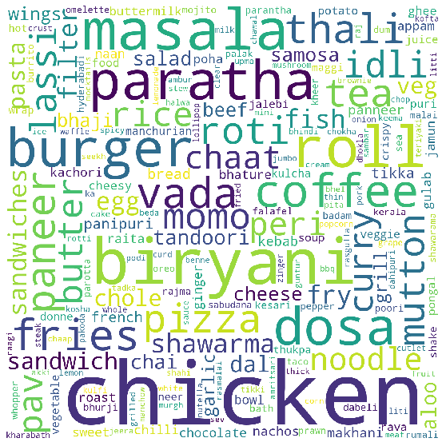

```python
plt.figure(figsize=(100,10))
dishes=''
for word in data['dish_liked']:
    words=word.split()
    # Converts each token into lowercase
    for i in range(len(words)):
        words[i] = words[i].lower()
    dishes=dishes+ " ".join(words)+" "
wordcloud = WordCloud(max_font_size=None, background_color='white', collocations=False,stopwords = stopwords,width=1500, height=1500).generate(dishes)
plt.imshow(wordcloud)
plt.axis("off")
```

# 205320002@iitb.ac.in